# Titanic: Machine Learning from Disaster

陳佳吟 Chia-Yin Chen

2017-07-01

# 1 Introduction

這份報告選擇了Kaggle的Titanic資料集，運用機器學習(machine learning)技術來預測鐵達尼號沉船後哪些乘客會存活下來。

## 1.1 匯入資料(Import Data)

首先讀取titanic的**訓練`train.csv`**與**測試`test.csv`**資料，其中test.csv是一個沒有Survived答案的csv檔案。

```r
# 資料讀取
titanic_train <- read.csv("data\\train.csv")
titanic_test <- read.csv("data\\test.csv")

# 新增`Set`變數來分辨訓練與測試資料
titanic_train$Set <- "Train"
titanic_test$Set <- "Test"

# 合併訓練與測試資料
titanic_test$Survived <- NA
full_data <- rbind(titanic_train, titanic_test)
```

## 1.2 觀察資料外觀(Data Overview)

```r
str(full_data) # The structure of titanic dataset
```

```
## 'data.frame':    1309 obs. of  13 variables:
##  $ PassengerId: int  1 2 3 4 5 6 7 8 9 10 ...
##  $ Survived   : int  0 1 1 1 0 0 0 0 1 1 ...
##  $ Pclass     : int  3 1 3 1 3 3 1 3 3 2 ...
##  $ Name       : Factor w/ 1307 levels "Abbing, Mr. Anthony",..: 109 191 358 277 16 559 520 629 417 581 ...
##  $ Sex        : Factor w/ 2 levels "female","male": 2 1 1 1 2 2 2 2 1 1 ...
##  $ Age        : num  22 38 26 35 35 NA 54 2 27 14 ...
##  $ SibSp      : int  1 1 0 1 0 0 0 3 0 1 ...
##  $ Parch      : int  0 0 0 0 0 0 0 1 2 0 ...
##  $ Ticket     : Factor w/ 929 levels "110152","110413",..: 524 597 670 50 473 276 86 396 345 133 ...
##  $ Fare       : num  7.25 71.28 7.92 53.1 8.05 ...
##  $ Cabin      : Factor w/ 187 levels "","A10","A14",..: 1 83 1 57 1 1 131 1 1 1 ...
##  $ Embarked   : Factor w/ 4 levels "","C","Q","S": 4 2 4 4 4 3 4 4 4 2 ...
##  $ Set        : chr  "Train" "Train" "Train" "Train" ...
```

得知titanic資料集有1309個觀測值與13個變數，[資料欄位說明](https://www.kaggle.com/c/titanic/data)如下表：

| Variable | Definition | Key |
| --- | --- | --- |
| PassengerId | 分配給每個乘客的唯一編號 |  |
| Survived | 生存與否的指標 | 0 = 死亡, 1 = 存活 |
| Pclass | 船票的艙等，代表社會經濟地位 | 1 = Upper, 2 = Middle, 3 = Lower |
| Name | 乘客姓名 |  |
| Sex | 乘客性別 |  |
| Age | 乘客年齡 (單位：年) |  |
| SibSp | 乘客的兄弟姐妹或配偶在船上的人數 |  |
| Parch | 乘客的父母或孩子在船上的人數 |  |
| Ticket | 船票編號 |  |
| Fare | 船票價格 |  |
| Cabin | 乘客佔用的客艙號碼 |  |
| Embarked | 乘客登船的港口 | C = Cherbourg, Q = Queenstown, S = Southampton |
| Set | 識別訓練與測試資料 |  |

```r
summary(full_data) # The summary of titanic dataset
```

```
##   PassengerId      Survived          Pclass
##  Min.   :   1   Min.   :0.0000   Min.   :1.000
##  1st Qu.: 328   1st Qu.:0.0000   1st Qu.:2.000
##  Median : 655   Median :0.0000   Median :3.000
##  Mean   : 655   Mean   :0.3838   Mean   :2.295
##  3rd Qu.: 982   3rd Qu.:1.0000   3rd Qu.:3.000
##  Max.   :1309   Max.   :1.0000   Max.   :3.000
##                 NA's   :418
##                                Name          Sex           Age
##  Connolly, Miss. Kate            :   2   female:466   Min.   : 0.17
##  Kelly, Mr. James                :   2   male  :843   1st Qu.:21.00
##  Abbing, Mr. Anthony             :   1                Median :28.00
##  Abbott, Mr. Rossmore Edward     :   1                Mean   :29.88
##  Abbott, Mrs. Stanton (Rosa Hunt):   1                3rd Qu.:39.00
##  Abelson, Mr. Samuel             :   1                Max.   :80.00
##  (Other)                         :1301                NA's   :263
##      SibSp            Parch            Ticket          Fare
##  Min.   :0.0000   Min.   :0.000   CA. 2343:  11   Min.   :  0.000
##  1st Qu.:0.0000   1st Qu.:0.000   1601    :   8   1st Qu.:  7.896
##  Median :0.0000   Median :0.000   CA 2144 :   8   Median : 14.454
##  Mean   :0.4989   Mean   :0.385   3101295 :   7   Mean   : 33.295
##  3rd Qu.:1.0000   3rd Qu.:0.000   347077  :   7   3rd Qu.: 31.275
##  Max.   :8.0000   Max.   :9.000   347082  :   7   Max.   :512.329
##                                   (Other) :1261   NA's   :1
##              Cabin      Embarked     Set
##                 :1014    :  2    Length:1309
##  C23 C25 C27    :   6   C:270    Class :character
##  B57 B59 B63 B66:   5   Q:123    Mode  :character
##  G6             :   5   S:914
##  B96 B98        :   4
##  C22 C26        :   4
##  (Other)        : 271
```

觀察到`Age`變數有263個遺漏值，`Fare`變數有1個遺漏值，`Cabin`變數有1014個空值，`Embarked`變數有2個空值，由於Cabin變數的空值太多了，因此在訓練模型時將不考慮加入此變數，其他Age、Fare、Embarked變數會在「遺漏值處理(Impute Missing Value)」的小節進行遺漏值填補。

# 2 特徵工程(Feature Engineering)

有句話讓我印象很深刻：**「數據和特徵決定了機器學習的上限，而模型和算法只是逼近這個上限而已」**。為了讓我的預測模型performance更出色，我需要為我的預測模型獲取到更好的訓練特徵資料。

## 2.1 Passenger Title

`Name`變數的格式為：“Surname(姓), Title(頭銜). Firstname(名)…”，可以從乘客姓名中將[頭銜(Title)](https://en.wikipedia.org/wiki/English_honorifics)提取出來成為有意義的資訊。

```r
# 自訂一個可以提取乘客Title的函數
get_Title <- function(data) {
  title_start <- regexpr(pattern = "\\,[A-Za-z ]{1,20}\\.", data$Name)
  title_end <- title_start + attr(title_start, "match.length") - 1
  data$Title <- substr(data$Name, start = title_start + 2, stop = title_end - 1)
  return(data$Title)
}

full_data$Title <- get_Title(full_data)
# 列出Title類別數量
table(full_data$Title)
```

```
##
##         Capt          Col          Don         Dona           Dr
##            1            4            1            1            8
##     Jonkheer         Lady        Major       Master         Miss
##            1            1            2           61          260
##         Mlle          Mme           Mr          Mrs           Ms
##            2            1          757          197            2
##          Rev          Sir the Countess
##            8            1            1
```

```r
# 整理歸類及重新定義一些Title
full_data$Title[full_data$Title %in% c("Capt", "Col", "Don", "Dona", "Dr", "Major", "Rev")] <- "Officer" # 高層職位
full_data$Title[full_data$Title %in% c("Lady", "the Countess", "Sir", "Jonkheer")] <- "Noble" # 貴族、皇族
full_data$Title[full_data$Title == "Mme"] <- "Mrs"  # 夫人、太太
full_data$Title[full_data$Title %in% c("Ms", "Mlle")] <- "Miss"  # 女士、小姐
full_data$Title <- factor(full_data$Title)

# 列出整理過後的Title類別數量
table(full_data$Title)
```

```
##
##  Master    Miss      Mr     Mrs   Noble Officer
##      61     264     757     198       4      25
```

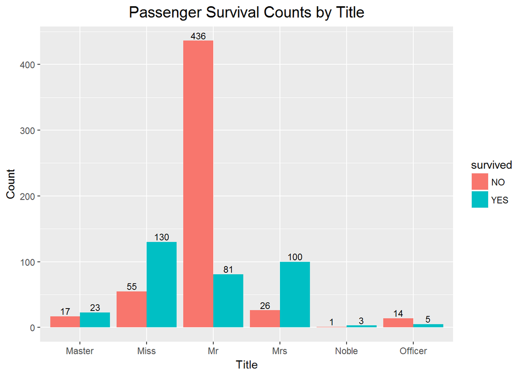

```r
# 視覺化`Title`與`Survived`之間的關係
library(ggplot2)
ggplot(full_data[full_data$Set == "Train", ], aes(x = Title, fill = factor(Survived))) +
  geom_bar(stat = "count", position = "dodge") +
  xlab("Title") +
  ylab("Count") +
  ggtitle("Passenger Survival Counts by Title") +
  theme(legend.position = "right",
        plot.title = element_text(size = 15, hjust = 0.5)) +
  scale_fill_discrete(guide = guide_legend(title = "survived"),
                      labels = c("NO", "YES")) +
  geom_text(stat = "count", aes(label = ..count..),
            position = position_dodge(width = 0.9), vjust = -0.25, size = 3)
```

可觀察到Title為**Miss**和**Mrs**存活的機會比較大，Title為**Mr**的存活機會明顯小很多，也間接告訴我們男性倖存者明顯少於女性。

## 2.2 Children vs. Women vs. Men

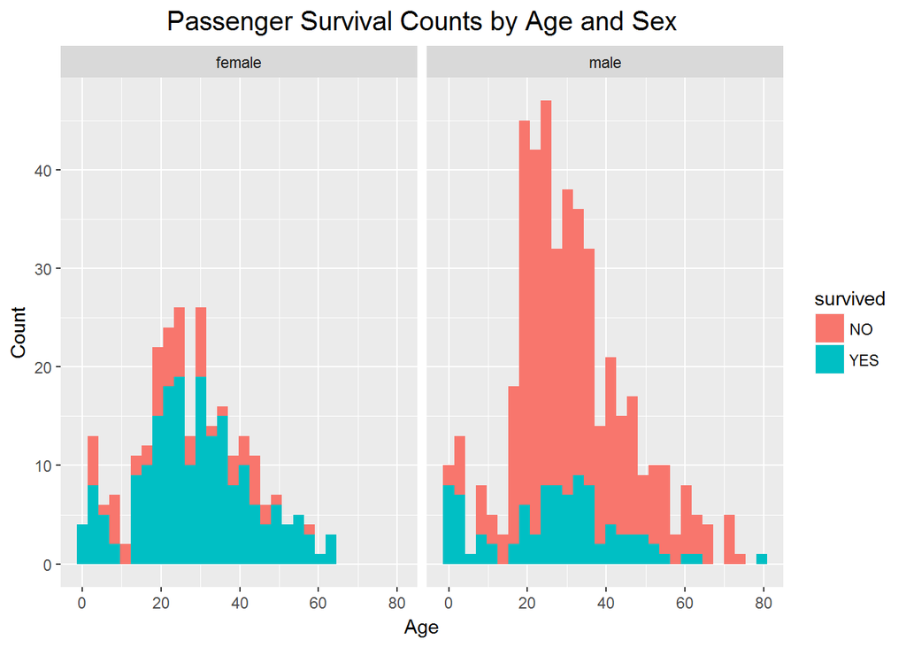

```r
# 視覺化`Age`在不同的`Sex`中與`Survived`之間的關係
ggplot(full_data[full_data$Set == "Train", ], aes(x = Age, fill = factor(Survived))) +
  geom_histogram() +
  facet_wrap(~ Sex) +
  xlab("Age") +
  ylab("Count") +
  ggtitle("Passenger Survival Counts by Age and Sex") +
  theme(legend.position = "right",
        plot.title = element_text(size = 15, hjust = 0.5)) +
  scale_fill_discrete(guide = guide_legend(title = "survived"),
                      labels = c("NO", "YES"))
```

視覺化明顯告訴我們不論在哪個年齡階段女性的存活機會都比較高，並可觀察到不論是在男性還是女性，15歲以下的孩童存活機會都比較高。因此決定以15歲來區分孩童及成人對`Survived`的影響。

```r
# 建立新的變數`Child`，辨識"孩童"、"成人"
full_data$Child[full_data$Age < 15] <- "Child"
full_data$Child[full_data$Age >= 15] <- "Adult"
full_data$Child <- factor(full_data$Child)
```

鐵達尼號逃生時究竟是老弱婦孺優先上救生艇？還是有錢人先上救生艇？

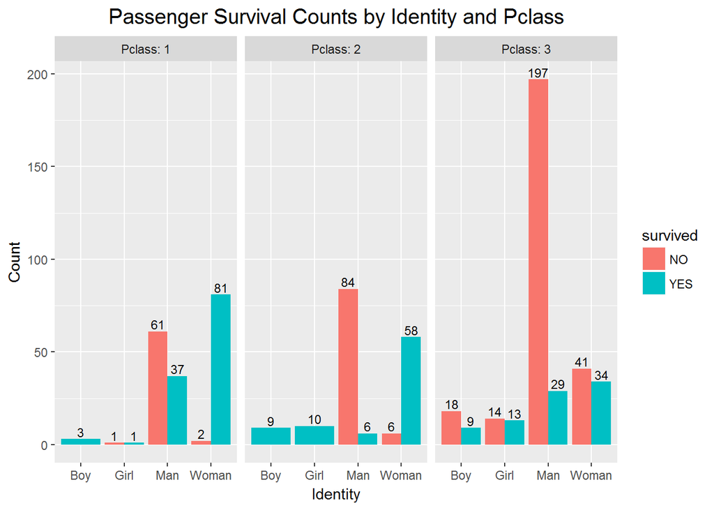

```r
# 建立新的變數`identity`，辨識"男性孩童"、"女性孩童"、"男性成人"、"女性成人"
full_data$identity[full_data$Age >= 15 & full_data$Sex == "male"] <- "Man"
full_data$identity[full_data$Age >= 15 & full_data$Sex == "female"] <- "Woman"
full_data$identity[full_data$Age < 15 & full_data$Sex == "male"] <- "Boy"
full_data$identity[full_data$Age < 15 & full_data$Sex == "female"] <- "Girl"
full_data$identity <- factor(full_data$identity)

# 視覺化`identity`在不同的`Pclass`中與`Survived`之間的關係
full_data$Pclass<- factor(full_data$Pclass)
ggplot(full_data[full_data$Set == "Train" & !is.na(full_data$Age), ],
       aes(x = identity, fill = factor(Survived))) +
  geom_bar(stat = "count", position = "dodge") +
  facet_wrap(~ Pclass, labeller = label_both) +
  xlab("Identity") +
  ylab("Count") +
  ggtitle("Passenger Survival Counts by Identity and Pclass") +
  theme(legend.position = "right",
        plot.title = element_text(size = 15, hjust = 0.5)) +
  scale_fill_discrete(guide = guide_legend(title = "survived"),
                      labels = c("NO", "YES")) +
  geom_text(stat = "count", aes(label = ..count..),
            position = position_dodge(width = 0.9), vjust = -0.25, size = 3)
```

註：【1】Boy：age < 15 & Sex == “male”【2】Girl：age < 15 & Sex == “female”【3】Man：Age >= 15 & Sex == “male”【4】Woman：Age >= 15 & Sex == “female”

視覺化顯示確實和電影演的一樣，逃生時婦女兒童優先上救生艇，大量的孩童和女性都存活了下來。但也發現到一個殘酷的事實，雖然船長發出了婦女和兒童優先上救生艇的口號，但逃生的機會還是取決於乘客當時所在的艙等，可發現Pclass = 3(Lower艙等)的乘客不管是孩童還是成人存活的機會都不高，Pclass = 1(Upper艙等)和Pclass = 2(Middle艙等)存活的機會高了些，所以其實只是Upper艙等和Middle艙等的婦女和兒童優先而已，間接說明了有錢人還是比窮人先活下來了…

## 2.3 Solo Travel vs. Group Travel

`SibSp`(兄弟姐妹或配偶在船上的人數)及`Parch`(直系的親人在船上的人數)這兩個變數包含了有關乘客家庭的隱藏資訊，利用這兩個變數製作一個新的變數叫作`family_size`(家庭人口大小)。

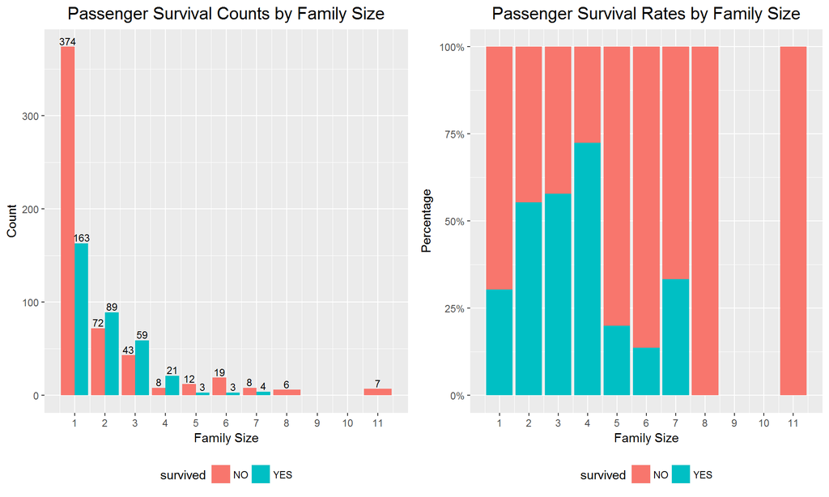

```r
# 建立新的變數`family_size`，包括乘客本人
full_data$family_size <- full_data$SibSp + full_data$Parch + 1

# 視覺化`family_size`與`Survived`之間的關係
library(gridExtra)
gg1 <- ggplot(full_data[full_data$Set == "Train", ], aes(x = family_size, fill = factor(Survived))) +
  geom_bar(stat = "count", position = "dodge") +
  scale_x_continuous(breaks = c(1:11)) +
  xlab("Family Size") +
  ylab("Count") +
  ggtitle("Passenger Survival Counts by Family Size") +
  theme(legend.position = "bottom",
        plot.title = element_text(size = 15, hjust = 0.5)) +
  scale_fill_discrete(guide = guide_legend(title = "survived"),
                      labels = c("NO", "YES")) +
  geom_text(stat = "count", aes(label = ..count..),
            position = position_dodge(width = 0.9), vjust = -0.25, size = 3)
gg2 <- ggplot(full_data[full_data$Set == "Train", ], aes(x = family_size, fill = factor(Survived))) +
  geom_bar(stat = "count", position = "fill") +
  scale_x_continuous(breaks = c(1:11)) +
  scale_y_continuous(labels = scales::percent) +
  xlab("Family Size") +
  ylab("Percentage") +
  ggtitle("Passenger Survival Rates by Family Size") +
  theme(legend.position = "bottom",
        plot.title = element_text(size = 15, hjust = 0.5)) +
  scale_fill_discrete(guide = guide_legend(title = "survived"),
                      labels = c("NO", "YES"))
grid.arrange(gg1, gg2, ncol=2)
```

上圖的視覺化告訴我們乘客的旅行人數是會影響生存情況的，不管是從「依照家庭人口數來計算倖存者的數量(左圖)」還是從「依照家庭人口數來劃分倖存者的比例(右圖)」的角度來看存活性，都可以發現“1 < 家庭人口 < 5”存活的可能性比“家庭人口 = 1”和“家庭人口 > 4”來的高。

另外，還可以再發現家庭人口為1的人數佔的好高！他們不是和家人一起旅遊，有可能是和朋友、情人、親友、傭人等人一起旅行，或者是獨自旅行。

所以呢只知道是否為家庭旅遊還不夠，我們再做更進階的探勘：一起購票的家庭或是團體似乎有相同的船票編號，利用`Ticket`變數(船票編號)來辨識乘客是獨自旅行還是團體旅行。最後再用視覺化來觀察一下！

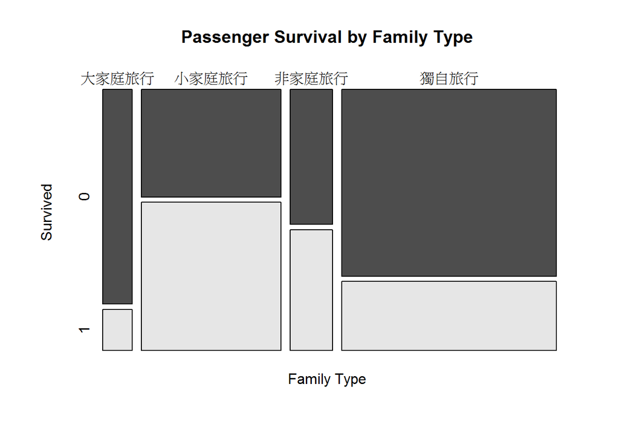

```r
# 將`family_size`變數分成"非家庭旅行"、"小家庭旅行"和"大家庭旅行"三個層面，存放在新建立的變數`family_type`，
full_data$family_type[full_data$family_size == 1] <- "非家庭旅行"
full_data$family_type[full_data$family_size > 1 & full_data$family_size < 5] <- "小家庭旅行"
full_data$family_type[full_data$family_size > 4] <- "大家庭旅行"
full_data$family_type <- factor(full_data$family_type)

# 使用`Ticket`變數製作`group_size`變數(團體旅遊人數)
library(magrittr)
library(dplyr)
full_data <- full_data %>%
  mutate(travel_group = match(Ticket, unique(Ticket)))

full_data$travel_group <- factor(full_data$travel_group)

full_data <- full_data %>%
  group_by(travel_group) %>%
  mutate(group_size = n())

# 將`非家庭旅行`及`團體旅遊人數為1人`的乘客認定為"獨自旅行"
full_data$family_type <- as.character(full_data$family_type)
full_data[full_data$family_type == "非家庭旅行" & full_data$group_size == 1, ]$family_type <- "獨自旅行"
full_data$family_type <- factor(full_data$family_type)

# 視覺化`family_type`與`Survived`之間的關係
library(vcd)
mosaicplot(full_data[full_data$Set == "Train", ]$family_type ~ full_data[full_data$Set == "Train", ]$Survived,
           main="Passenger Survival by Family Type",
           shade = FALSE, color = TRUE,
           xlab = "Family Type", ylab = "Survived",
           cex.axis = 1)
```

註：視覺化中的**非家庭旅行**包括朋友、情人、親友、傭人等人一起旅行。

可觀察到大多數的乘客都是“獨自旅行”的，但存活的比例似乎不太高，反而是“小家庭旅行”存活的機會大於50%，

# 3 遺漏值處理(Impute Missing Value)

**———————————————————————————–遺漏值：Embarked————————————————————————————**

```r
# 看一下`Embarked`2個空值的觀測值
data.frame(full_data[full_data$Embarked == "", ])
```

```
##   PassengerId Survived Pclass                                      Name
## 1          62        1      1                       Icard, Miss. Amelie
## 2         830        1      1 Stone, Mrs. George Nelson (Martha Evelyn)
##      Sex Age SibSp Parch Ticket Fare Cabin Embarked   Set Title Child
## 1 female  38     0     0 113572   80   B28          Train  Miss Adult
## 2 female  62     0     0 113572   80   B28          Train   Mrs Adult
##   identity family_size family_type travel_group group_size
## 1    Woman           1  非家庭旅行           61          2
## 2    Woman           1  非家庭旅行           61          2
```

可以觀察到編號62和830的乘客資訊很相似，差別只在於年紀的不同而已，同樣支付了$80票價，且都是Upper艙等，但都不知道是從哪個港口上船的。我們假設相同票價的乘客是在同一個港口上船的，可以用**票價Fare**和**艙等Pclass**來推估乘客會從哪一個**港口出發Embarked**。

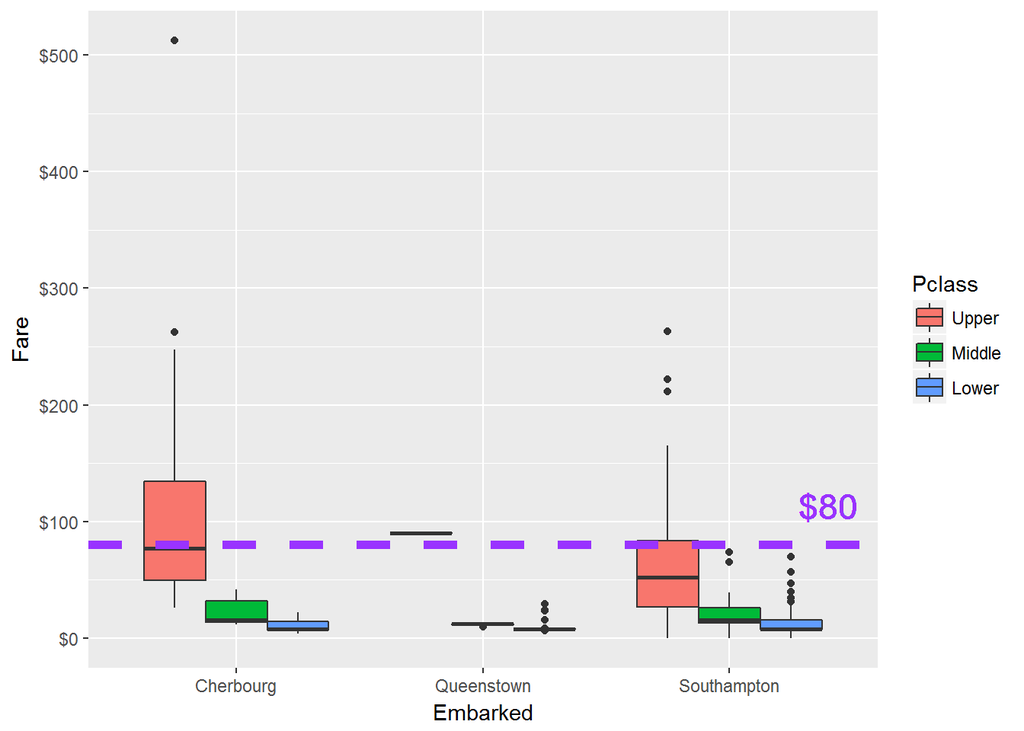

```r
# 視覺化`Fare`、`Embarked`與`Pclass`之間的關係
ggplot(full_data[full_data$Embarked != "", ], aes(x = Embarked, y = Fare, fill = Pclass)) +
  geom_boxplot() +
  geom_hline(aes(yintercept = 80),
             colour = "#9933ff", lty = 2, size = 2) +
  scale_y_continuous(labels = scales::dollar) +
  geom_text(aes(3.4, 80, label = "$80", vjust = -1), size = 6, colour = "#9933ff") +
  scale_fill_discrete(guide = guide_legend(title = "Pclass"),
                      labels = c("Upper", "Middle", "Lower")) +
  scale_x_discrete(labels = c("Cherbourg", "Queenstown", "Southampton"))
```

編號62和830乘客支付的費用$80洽好和從Cherbourg港口出發的Upper艙等乘客中位票價一樣，因此他們很有可能是從Cherbourg港口上船的，我們可以用“C”替換空值。

```r
# 填補`Embarked`遺漏值
full_data$Embarked <- as.character(full_data$Embarked)
full_data[full_data$Embarked == "", ]$Embarked <- "C"
full_data$Embarked <- factor(full_data$Embarked)
```

**—————————————————————————————–遺漏值：Fare————————————————————————————–**

```r
# 看一下遺漏`Fare`的觀測值
data.frame(full_data[is.na(full_data$Fare), ])
```

```
##   PassengerId Survived Pclass               Name  Sex  Age SibSp Parch
## 1        1044       NA      3 Storey, Mr. Thomas male 60.5     0     0
##   Ticket Fare Cabin Embarked  Set Title Child identity family_size
## 1   3701   NA              S Test    Mr Adult      Man           1
##   family_type travel_group group_size
## 1    獨自旅行          779          1
```

可以知道編號1044的乘客是從Southampton港口出發的Lower艙等，但不知道票價是多少。我們可以用剛剛填補登船港口遺漏值的思維，用**港口出發Embarked**地點和**艙等Pclass**來推估乘客會落在哪一個**票價Fare**。

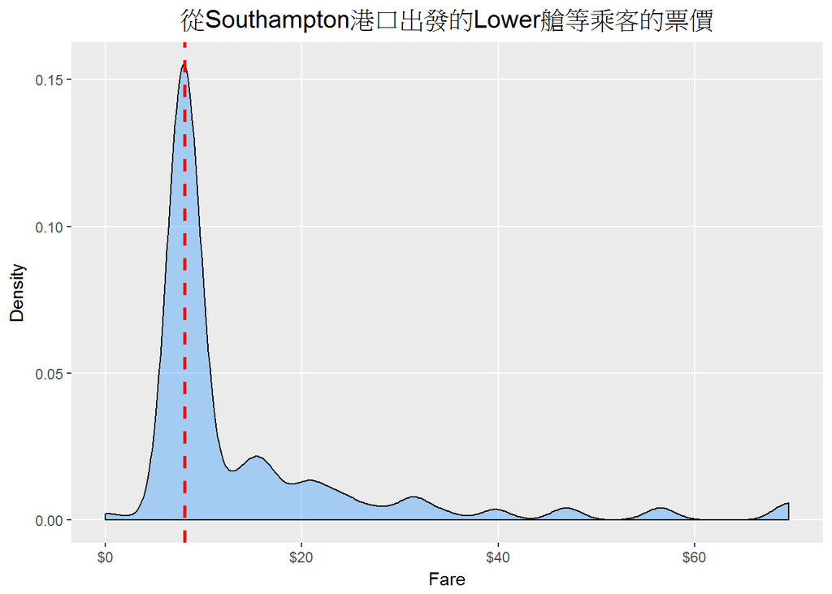

```r
# 視覺化從Southampton港口出發的Lower艙等乘客的票價
ggplot(full_data[full_data$Pclass == "3" & full_data$Embarked == "S", ], aes(x = Fare)) +
  geom_density(fill = "#0080ff", alpha=0.3) +
  geom_vline(aes(xintercept = median(Fare, na.rm = TRUE)),  # Pclass=3 & Embarked="S"的median Fare
             colour = "red", lty = 2, size = 1) +
  scale_x_continuous(labels = scales::dollar) +
  xlab("Fare") +
  ylab("Density") +
  ggtitle("從Southampton港口出發的Lower艙等乘客的票價") +
  theme(plot.title = element_text(size = 15, hjust = 0.5),
        panel.grid.minor = element_blank())
```

從Southampton港口出發的Lower艙等乘客的票價大部分分布在$0~$20之間，資料呈現右偏分配，存在比較大的離群值，由於中位數較平均數不容易受離群值的影響，因此標一條紅色虛線表示中位數來觀察一下，意外的發現票價的中位數恰好為眾數！我們可以將編號1044乘客的遺漏值`Fare`用中位數來替換，對於這個乘客付出這樣的價錢似乎也蠻合理的。

```r
# 依照乘客所屬`Pclass`與`Embarked`的中位數替換票價遺漏值
full_data[is.na(full_data$Fare), ]$Fare <- median(full_data[full_data$Pclass == "3" & full_data$Embarked == "S", ]$Fare, na.rm = TRUE)
```

**—————————————————————————————遺漏值：Age—————————————————————————————–**

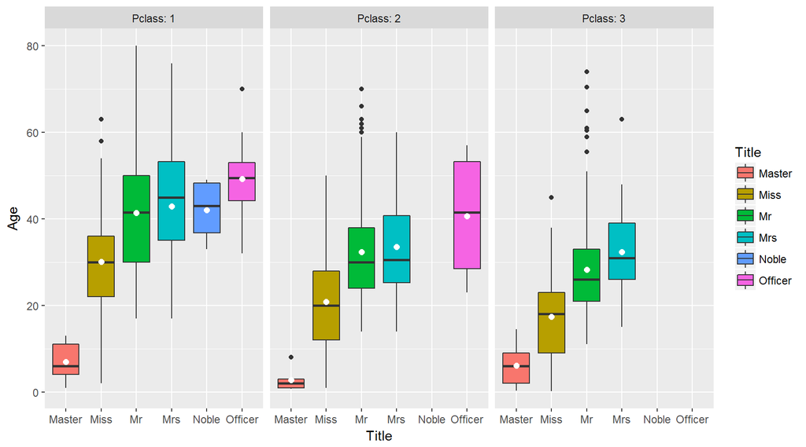

```r
# 視覺化`Title`在不同的`Pclass`中與`Age`之間的關係
ggplot(full_data, aes(x = Title, y = Age, fill = Title)) +
  geom_boxplot() +
  facet_wrap(~ Pclass, labeller = label_both) +
  stat_summary(fun.y = mean, colour = "white", geom = "point", size = 2, show_guide = FALSE)
```

發現艙等等級會隨著年齡而變化，年齡越大的乘客購買艙等的等級就越高。在Pclass = 1(Upper艙等)乘客的年齡普遍都比較大，且Title為Master乘客的年齡都頗小的。

資料中存在離群值，因此標一個白色圓點表示平均值，來觀察平均值是否受離群值影響很大。視覺化顯示平均值和中位數兩者間的差異沒有到很大，因此決定把遺漏值`Age`依照`Title`與`Pclass`的平均年齡進行填補。

```r
# 結合`Title`與`Pclass`計算平均年齡
mean_age_by_Title_and_Pclass <- full_data %>%
  group_by(Title, Pclass) %>%
  summarise(mean_age = round(mean(Age, na.rm = TRUE), 2))
mean_age_by_Title_and_Pclass
```

```
## Source: local data frame [15 x 3]
## Groups: Title [?]
##
##      Title Pclass mean_age
##     <fctr> <fctr>    <dbl>
## 1   Master      1     6.98
## 2   Master      2     2.76
## 3   Master      3     6.09
## 4     Miss      1    30.13
## 5     Miss      2    20.87
## 6     Miss      3    17.36
## 7       Mr      1    41.45
## 8       Mr      2    32.35
## 9       Mr      3    28.32
## 10     Mrs      1    42.93
## 11     Mrs      2    33.52
## 12     Mrs      3    32.33
## 13   Noble      1    42.00
## 14 Officer      1    49.29
## 15 Officer      2    40.70
```

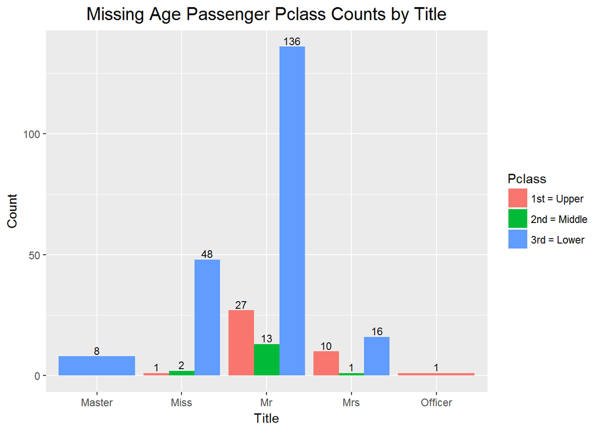

```r
# 視覺化Age為遺漏值的乘客`Title`與`Pclass`之間的關係
ggplot(full_data[is.na(full_data$Age), ], aes(x = Title, fill = Pclass)) +
  geom_bar(stat = "count", position = "dodge") +
  xlab("Title") +
  ylab("Count") +
  ggtitle("Missing Age Passenger Pclass Counts by Title") +
  theme(legend.position = "right",
        plot.title = element_text(size = 15, hjust = 0.5)) +
  scale_fill_discrete(guide = guide_legend(title = "Pclass"),
                      labels = c("1st = Upper", "2nd = Middle", "3rd = Lower")) +
  geom_text(stat = "count", aes(label = ..count..),
            position = position_dodge(width = 0.9), vjust = -0.25, size = 3)
```

可注意到在Age為遺漏值的乘客中，並不是每個Title類別在三個艙等都有遺漏值，例如Title為Master的乘客中Age為遺漏值的只有在Lower艙等而已，Title為Noble的乘客中Age皆無遺漏值，以此類推…。因此在填補Age遺漏值時要與mean_age_by_Title_and_Pclass的順序對應好。

```r
# 依照`Title`與`Pclass`的平均年齡替換年齡遺漏值
full_data[is.na(full_data$Age) & full_data$Title == "Master" & full_data$Pclass == "3", ]$Age <- mean_age_by_Title_and_Pclass$mean_age[3]
full_data[is.na(full_data$Age) & full_data$Title == "Miss" & full_data$Pclass == "1", ]$Age <- mean_age_by_Title_and_Pclass$mean_age[4]
full_data[is.na(full_data$Age) & full_data$Title == "Miss" & full_data$Pclass == "2", ]$Age <- mean_age_by_Title_and_Pclass$mean_age[5]
full_data[is.na(full_data$Age) & full_data$Title == "Miss" & full_data$Pclass == "3", ]$Age <- mean_age_by_Title_and_Pclass$mean_age[6]
full_data[is.na(full_data$Age) & full_data$Title == "Mr" & full_data$Pclass == "1", ]$Age <- mean_age_by_Title_and_Pclass$mean_age[7]
full_data[is.na(full_data$Age) & full_data$Title == "Mr" & full_data$Pclass == '2', ]$Age <- mean_age_by_Title_and_Pclass$mean_age[8]
full_data[is.na(full_data$Age) & full_data$Title == "Mr" & full_data$Pclass == "3", ]$Age <- mean_age_by_Title_and_Pclass$mean_age[9]
full_data[is.na(full_data$Age) & full_data$Title == "Mrs" & full_data$Pclass == "1", ]$Age <- mean_age_by_Title_and_Pclass$mean_age[10]
full_data[is.na(full_data$Age) & full_data$Title == "Mrs" & full_data$Pclass == "2", ]$Age <- mean_age_by_Title_and_Pclass$mean_age[11]
full_data[is.na(full_data$Age) & full_data$Title == "Mrs" & full_data$Pclass == "3", ]$Age <- mean_age_by_Title_and_Pclass$mean_age[12]
full_data[is.na(full_data$Age) & full_data$Title == "Officer" & full_data$Pclass == "1", ]$Age <- mean_age_by_Title_and_Pclass$mean_age[14]

# 完成年齡遺漏值填補後，對之前還沒有辨識到`identity`的乘客再做一次辨識
full_data$identity <- as.character(full_data$identity)
full_data$identity[full_data$Age >= 15 & full_data$Sex == "male"] <- "Man"
full_data$identity[full_data$Age >= 15 & full_data$Sex == "female"] <- "Woman"
full_data$identity[full_data$Age < 15 & full_data$Sex == "male"] <- "Boy"
full_data$identity[full_data$Age < 15 & full_data$Sex == "female"] <- "Girl"
full_data$identity <- factor(full_data$identity)

# 完成年齡遺漏值填補後，對之前還沒有辨識到`Child`的乘客再做一次辨識
full_data$Child <- as.character(full_data$Child)
full_data$Child[full_data$Age < 15] <- "Child"
full_data$Child[full_data$Age >= 15] <- "Adult"
full_data$Child <- factor(full_data$Child)
```

檢查titanic資料集是否還有遺漏值的存在。

```r
# 計算遺漏值數量
sum(is.na(full_data %>% select(-Survived)))
```

```
## [1] 0
```

```r
# 填補遺漏值後的summary
summary(full_data)
```

```
##   PassengerId      Survived      Pclass
##  Min.   :   1   Min.   :0.0000   1:323
##  1st Qu.: 328   1st Qu.:0.0000   2:277
##  Median : 655   Median :0.0000   3:709
##  Mean   : 655   Mean   :0.3838
##  3rd Qu.: 982   3rd Qu.:1.0000
##  Max.   :1309   Max.   :1.0000
##                 NA's   :418
##                                Name          Sex           Age
##  Connolly, Miss. Kate            :   2   female:466   Min.   : 0.17
##  Kelly, Mr. James                :   2   male  :843   1st Qu.:21.00
##  Abbing, Mr. Anthony             :   1                Median :28.32
##  Abbott, Mr. Rossmore Edward     :   1                Mean   :29.51
##  Abbott, Mrs. Stanton (Rosa Hunt):   1                3rd Qu.:36.50
##  Abelson, Mr. Samuel             :   1                Max.   :80.00
##  (Other)                         :1301
##      SibSp            Parch            Ticket          Fare
##  Min.   :0.0000   Min.   :0.000   CA. 2343:  11   Min.   :  0.000
##  1st Qu.:0.0000   1st Qu.:0.000   1601    :   8   1st Qu.:  7.896
##  Median :0.0000   Median :0.000   CA 2144 :   8   Median : 14.454
##  Mean   :0.4989   Mean   :0.385   3101295 :   7   Mean   : 33.276
##  3rd Qu.:1.0000   3rd Qu.:0.000   347077  :   7   3rd Qu.: 31.275
##  Max.   :8.0000   Max.   :9.000   347082  :   7   Max.   :512.329
##                                   (Other) :1261
##              Cabin      Embarked     Set                Title
##                 :1014   C:272    Length:1309        Master : 61
##  C23 C25 C27    :   6   Q:123    Class :character   Miss   :264
##  B57 B59 B63 B66:   5   S:914    Mode  :character   Mr     :757
##  G6             :   5                               Mrs    :198
##  B96 B98        :   4                               Noble  :  4
##  C22 C26        :   4                               Officer: 25
##  (Other)        : 271
##    Child       identity    family_size         family_type   travel_group
##  Adult:1192   Boy  : 66   Min.   : 1.000   大家庭旅行: 82   149    :  11
##  Child: 117   Girl : 51   1st Qu.: 1.000   小家庭旅行:437   59     :   8
##               Man  :777   Median : 1.000   非家庭旅行:127   73     :   8
##               Woman:415   Mean   : 1.884   獨自旅行  :663   14     :   7
##                           3rd Qu.: 2.000                    25     :   7
##                           Max.   :11.000                    50     :   7
##                                                             (Other):1261
##    group_size
##  Min.   : 1.000
##  1st Qu.: 1.000
##  Median : 1.000
##  Mean   : 2.102
##  3rd Qu.: 3.000
##  Max.   :11.000
##
```

titanic資料集中的`Age`、`Fare`、`Embarked`都沒有遺漏值的存在了，可以進行後續的建模啦！

# 4 訓練模型(Training a Model)

使用機器學習的`隨機森林(randomForest)`演算法在訓練資料上建構我們的模型。

## 4.1 變數選擇(Variable Selection)

回顧一下「特徵工程(Feature Engineering)」小節，我們利用titanic資料集原始存在的變數衍生出很多新的變數，也發現那些衍生出來的變數都對`Survived`有一定的影響力，而在選擇模型的預測變數時，有重疊的變數我們將擇一選擇。變數選擇結果如下表：

| 原始變數 | 衍生變數 | 變數選擇 |
| --- | --- | --- |
| Pclass |  | Pclass |
| Name | Title | Title |
| Sex |  | Sex |
| Age | Child | Child |
| Sex & Age | identity |  |
| SibSp & Parch | family_size、family_type | family_type |
| Ticket | group_size | group_size |
| Fare |  | Fare |
| Embarked |  | Embarked |

`PassengerId`變數基本上每個乘客都不一樣，`Cabin`變數的遺漏值缺失很嚴重，所以在訓練模型時不考慮這兩個變數。

## 4.2 建立分類模型(Building a Classification Model)

```r
full_data$Survived <- factor(full_data$Survived, levels = c("1", "0"))

# 將train資料提取出來作為訓練模型的資料
modeling_data <- full_data[full_data$Set == "Train", ]

# 找出決策樹進行分裂時所選擇的特徵個數之最佳值(mtry)
library(randomForest)
model_err_rate = 1
for(i in 1:8)  # 8為Pclass, Sex, Child, Fare, Embarked, Title, family_type, group_size
{
  set.seed(754)
  result = randomForest(Survived ~ Pclass + Sex + Child + Fare + Embarked + Title + family_type + group_size, data = modeling_data, mtry = i, ntree = 500)
  model_err_rate[i] = mean(result$err.rate)
}
mtry_value = which.min(model_err_rate)

# 建立randomForest分類器
set.seed(754)
rfModel <- randomForest(Survived ~ Pclass + Sex + Child + Fare + Embarked + Title + family_type + group_size, data = modeling_data, mtry = mtry_value, ntree = 500)
```

## 4.3 變數的重要性(Variable Importance)

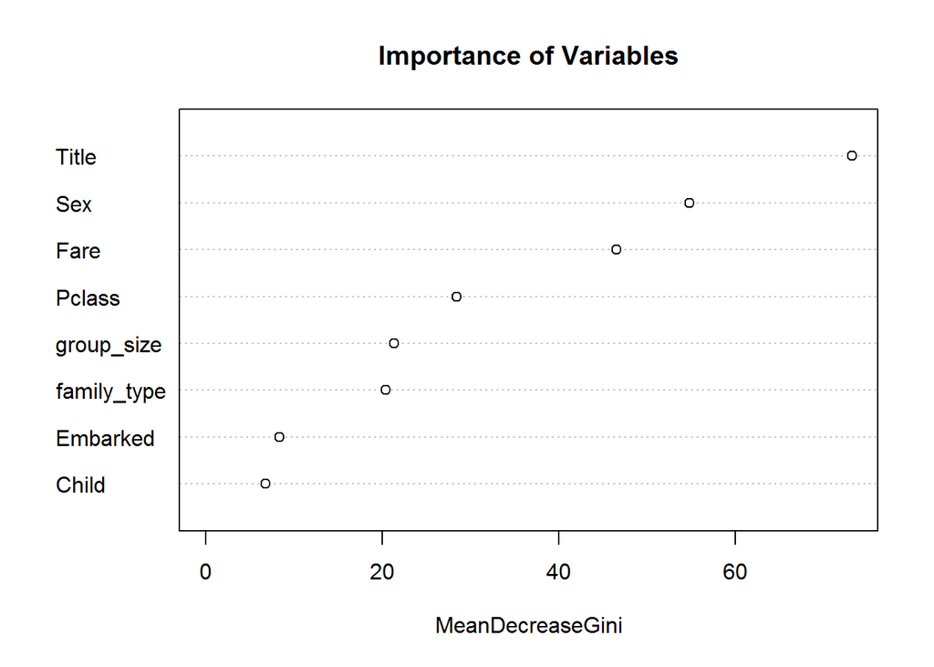

```r
# plot variable importance
varImpPlot(rfModel, main = "Importance of Variables")
```

```r
# output variable importance
round(importance(rfModel), 2)
```

```
##             MeanDecreaseGini
## Pclass                 28.40
## Sex                    54.76
## Child                   6.78
## Fare                   46.56
## Embarked                8.34
## Title                  73.16
## family_type            20.42
## group_size             21.39
```

上面結果顯示了各個變數的節點純度，也就是說變數在分資料群時是否有判斷性，值愈高表示該變數對於模型的判別影響力愈大，可以作為往後利用其他演算法進行建模時刪減變數的依據。結果令我很訝異…從乘客姓名衍生出來的**Title**變數竟然最為重要！

# 5 衡量模型表現(Evaluating Model Performance)

## 5.1 模型錯誤率(Model Error)

```r
rfModel
```

```
##
## Call:
##  randomForest(formula = Survived ~ Pclass + Sex + Child + Fare +      Embarked + Title + family_type + group_size, data = modeling_data,      mtry = mtry_value, ntree = 500)
##                Type of random forest: classification
##                      Number of trees: 500
## No. of variables tried at each split: 2
##
##         OOB estimate of  error rate: 16.05%
## Confusion matrix:
##     1   0 class.error
## 1 246  96   0.2807018
## 0  47 502   0.0856102
```

對OOB樣本進行預測，錯誤率為16.05%。 註：out-of-bag(OOB)為每次抽樣中的袋外樣本

從混淆矩陣(Confusion Matrix)可看出：

- 模型將原本為1(存活)的正確預測為1(存活)的有246筆
- 模型將原本為1(存活)的錯誤預測為0(死亡)的有96筆
- 1(存活)的誤判率有28.07%
- 模型將原本為0(死亡)的正確預測為0(死亡)的有502筆
- 模型將原本為0(死亡)的錯誤預測為1(存活)的有47筆
- 0(死亡)的誤判率有8.56%

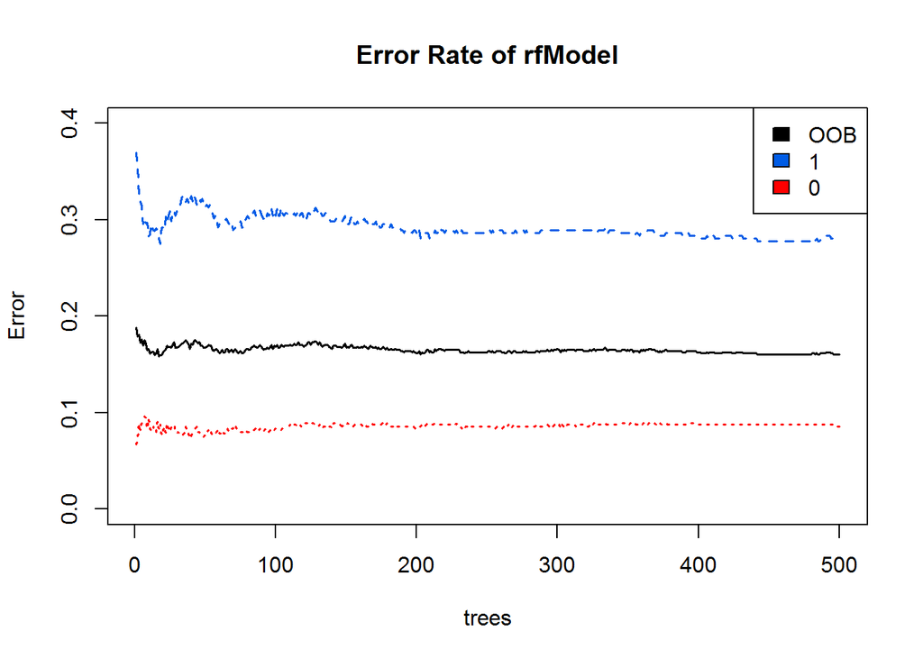

```r
plot(rfModel, col = c("#000000", "#005ce6", "#ff0000"), lwd = 1.5,
     ylim=c(0,0.4), main = "Error Rate of rfModel")
legend("topright", legend = colnames(rfModel$err.rate),
       col = c("#000000", "#005ce6", "#ff0000"), fill = c("#000000", "#005ce6", "#ff0000"))
```

上圖顯示了randomForest模型的錯誤率，黑線顯示總體錯誤率低於20%。藍線和紅線分別顯示“存活”和“死亡”的錯誤率，可以看到死亡的預測效果比預測存活還要好，而且預測存活的錯誤率比總體錯誤率還要高，為什麼會這樣呢？這是一個值得思考的問題！

## 5.2 模型準確度(Model Accuracy)

```r
# 計算accuracy
prediction <- predict(rfModel)
confusion_matrix <- table(modeling_data$Survived, prediction)
accuracy <- sum(diag(confusion_matrix)) / sum(confusion_matrix)
accuracy
```

```
## [1] 0.8395062
```

## 5.3 ROC曲線(ROC Curve)

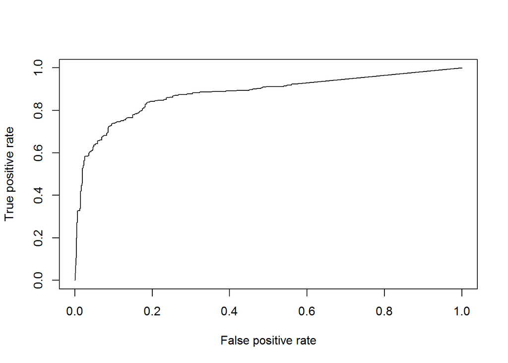

```r
# ROC Curve
library(ROCR)
probabilities <- predict(rfModel, type = "prob")[,1]
pred <- prediction(probabilities, labels = modeling_data$Survived)
perf <- performance(pred, "tpr", "fpr")
plot(perf)
```

```r
# 計算AUC(計算ROC曲線底下的面積)
perf <- performance(pred, "auc")
perf@y.values[[1]]
```

```
## [1] 0.8787082
```

# 6 Making our prediction

是時候來預測了！現在將使用上面所建立好的RandomForest模型應用在titanic中的測試資料`test.csv`來預測`Survived`。

```r
# 將test資料提取出來做預測
predict_data <- full_data[full_data$Set == "Test", ]

# 對test資料做預測
predicted <- predict(rfModel, newdata = predict_data)

# 依照競賽的Submission File Format，產出2個欄位的檔案：PassengerId、Survived(predicted)
solution <- data.frame(PassengerId = predict_data[, "PassengerId"], Survived = predicted)

# 看一下solution的前10筆資料
head(solution, n = 10)
```

```
##    PassengerId Survived
## 1          892        0
## 2          893        1
## 3          894        0
## 4          895        0
## 5          896        1
## 6          897        0
## 7          898        1
## 8          899        0
## 9          900        1
## 10         901        0
```

```r
# 將solution匯出為csv檔案
write.csv(solution, file = "r_randomForest_submission.csv", row.names = FALSE, quote = FALSE)
```